# Ford GoBike System Data Exploration

## by Demilade Aliu

## Overview

In this investigation, I wanted to explore the properties associated with the user type of the Ford GoBike System Data. The main focus was on age, time(Hour, weekday), duration and gender.

## Dataset Overview

The data consists of information regarding 183,412 rows and 15 columns, including, member details, trip duration and time details. 8,460 data points were removed from the analysis due to inconsistencies or missing information.

## User type

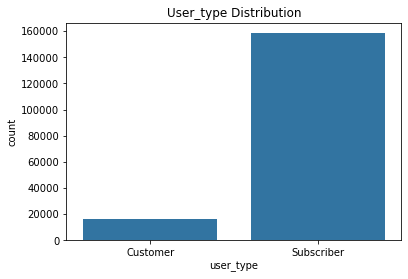

## Distribution of Age

Age has a right skewed distribution, with most of the age roughly between 20 and 60 years. When scaled by changing the binsize and limiting the x axis, the age distribution is unimodal, peaking at around 30 years and 35 years.

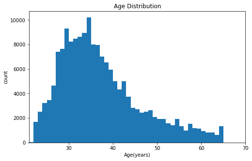

## Distribution of Duration

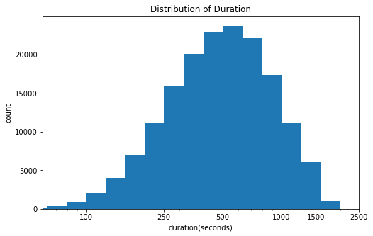

## Relationship between User type and Age, Duration

> Though there are more Subcribers, interestingly customer users take longer trips. It would be interesting to dive deep into what might be the causation. Also Subscribers are older than customers.

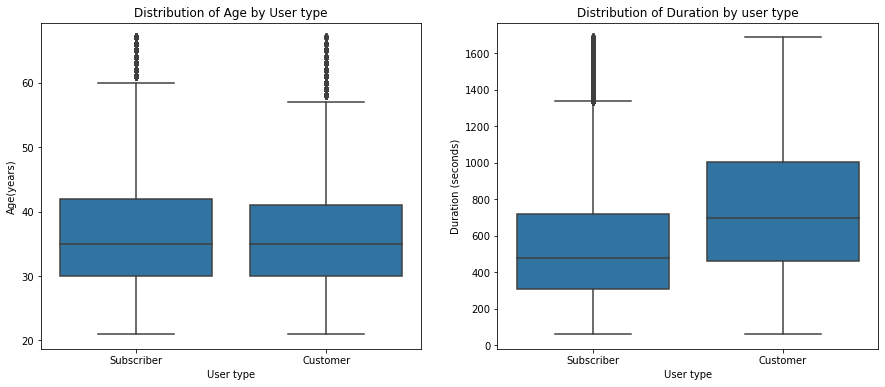

## User type and Time

> Subscribers have a drop in bike usage on weekends, while theres really no difference in bike usage for all days for customers asides thursday.

> Subscribers take trips mostly during 8am and 5 pm which falls in working hour. customers take trips between 8am and 6pm

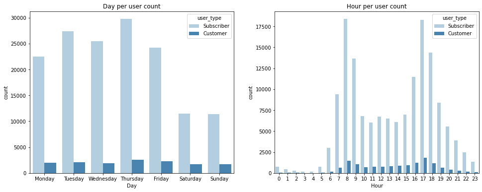

## Why do customers take longer trip compared to subscribers?

> There is an increase in the trip duration on Saturday even for Subscribers. While the trip duration is significant on weekends for customers. There are lots of outliers in the early hours, however there seem to be an inverse relationship in the hours of trip

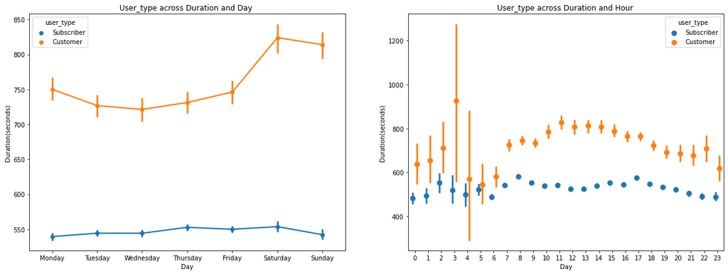

## Time count for each users

> While there are similaries in counts, its shown that for Customers, there are more trip rides on saturdays and sundays particularly between 10am and 5pm.

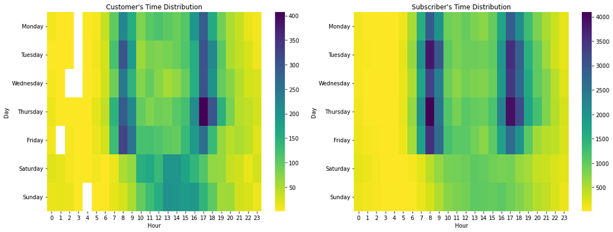

## Trip duration across age for each users

> While its is evident that the longer the trip, the younger the age. The trip duration covers more area for customers compared to subscribers.

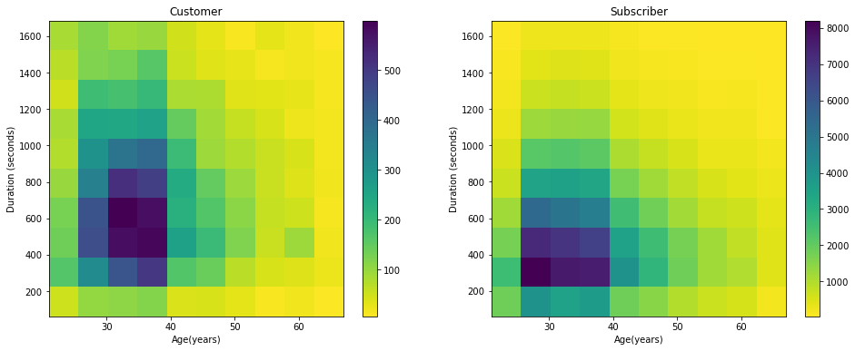